[dblogr/](https://derekmichaelwright.github.io/dblogr)

# R Tutorial

An introduction to R

# Introduction

[figure not shown]

R Project Logo

# Download

> - Download at https://www.r-project.org/
> - Download `RStudio` at https://rstudio.com/products/rstudio/download/

[figure not shown]

## Other Useful Tutorials

> - http://r-statistics.co/R-Tutorial.html
> - https://bookdown.org/rdpeng/exdata/getting-started-with-r.html#installation

# Calculator

```r
# 5 + 3 = 8
5 + 3
```

```
## [1] 8
```

```r
# 24 / (1 + 2) = 8
24 / (1 + 2)
```

```
## [1] 8
```

```r
# 2 * 2 * 2 = 8
2^3
```

```
## [1] 8
```

```r
# 8 * 8 = 64
sqrt(64)
```

```
## [1] 8
```

```r
# -log10(0.05 / 5000000) = 8
-log10(0.05 / 5000000)
```

```
## [1] 8
```

# Functions

```r
1:10
```

```
##  [1]  1  2  3  4  5  6  7  8  9 10
```

```r
as.character(1:10)
```

```
##  [1] "1"  "2"  "3"  "4"  "5"  "6"  "7"  "8"  "9"  "10"
```

```r
rep(1:2, times = 5)
```

```
##  [1] 1 2 1 2 1 2 1 2 1 2
```

```r
rep(1:5, times = 2)
```

```
##  [1] 1 2 3 4 5 1 2 3 4 5
```

```r
rep(1:5, each = 2)
```

```
##  [1] 1 1 2 2 3 3 4 4 5 5
```

```r
rep(1:5, length.out = 7)
```

```
## [1] 1 2 3 4 5 1 2
```

```r
seq(5, 50, by = 5)
```

```
##  [1]  5 10 15 20 25 30 35 40 45 50
```

```r
seq(5, 50, length.out = 5)
```

```
## [1]  5.00 16.25 27.50 38.75 50.00
```

```r
paste(1:10, 20:30, sep = "-")
```

```
##  [1] "1-20"  "2-21"  "3-22"  "4-23"  "5-24"  "6-25"  "7-26"  "8-27"  "9-28"  "10-29" "1-30"
```

```r
paste(1:10, collapse = "-")
```

```
## [1] "1-2-3-4-5-6-7-8-9-10"
```

```r
paste0("x", 1:10)
```

```
##  [1] "x1"  "x2"  "x3"  "x4"  "x5"  "x6"  "x7"  "x8"  "x9"  "x10"
```

```r
min(1:10)
```

```
## [1] 1
```

```r
max(1:10)
```

```
## [1] 10
```

```r
range(1:10)
```

```
## [1]  1 10
```

```r
mean(1:10)
```

```
## [1] 5.5
```

```r
sd(1:10)
```

```
## [1] 3.02765
```

## Custom Functions

Users can also create their own functions

```r
customFunction1 <- function(x, y) {
  z <- 100 * x / (x + y)
  paste(z, "%")
}
customFunction1(x = 10, y = 90)
```

```
## [1] "10 %"
```

```r
customFunction2 <- function(x) {
  mymin <- mean(x - sd(x))
  mymax <- mean(x) + sd(x)
  print(paste("Min =", mymin))
  print(paste("Max =", mymax))
}
customFunction2(x = 1:10)
```

```
## [1] "Min = 2.47234964590251"
## [1] "Max = 8.52765035409749"
```

## `for` loops and `if` `else` statements

```r
xx <- NULL #creates and empty object
for(i in 1:10) {
  xx[i] <- i*3
}
xx
```

```
##  [1]  3  6  9 12 15 18 21 24 27 30
```

```r
xx %% 2 #gives the remainder when divided by 2
```

```
##  [1] 1 0 1 0 1 0 1 0 1 0
```

```r
for(i in 1:length(xx)) {
  if((xx[i] %% 2) == 0) {
    print(paste(xx[i],"is Even"))
  } else {
      print(paste(xx[i],"is Odd"))
    }
}
```

```
## [1] "3 is Odd"
## [1] "6 is Even"
## [1] "9 is Odd"
## [1] "12 is Even"
## [1] "15 is Odd"
## [1] "18 is Even"
## [1] "21 is Odd"
## [1] "24 is Even"
## [1] "27 is Odd"
## [1] "30 is Even"
```

```r
# or
ifelse(xx %% 2 == 0, "Even", "Odd")
```

```
##  [1] "Odd"  "Even" "Odd"  "Even" "Odd"  "Even" "Odd"  "Even" "Odd"  "Even"
```

```r
paste(xx, ifelse(xx %% 2 == 0, "is Even", "is Odd"))
```

```
##  [1] "3 is Odd"   "6 is Even"  "9 is Odd"   "12 is Even" "15 is Odd"  "18 is Even" "21 is Odd"  "24 is Even" "27 is Odd"  "30 is Even"
```

# Objects

Information can be stored in user defined objects, in multiple forms:

- `c()`: a string of values
- `matrix()`: a two dimensional matrix in one format
- `data.frame()`: a two dimensional matrix where each column can be a different format
- `list()`:

## A string…

```r
xc <- 1:10
xc
```

```
##  [1]  1  2  3  4  5  6  7  8  9 10
```

```r
xc <- c(1,2,3,4,5,6,7,8,9,10)
xc
```

```
##  [1]  1  2  3  4  5  6  7  8  9 10
```

## A matrix…

```r
xm <- matrix(1:100, nrow = 10, ncol = 10, byrow = T)
xm
```

```
##       [,1] [,2] [,3] [,4] [,5] [,6] [,7] [,8] [,9] [,10]
##  [1,]    1    2    3    4    5    6    7    8    9    10
##  [2,]   11   12   13   14   15   16   17   18   19    20
##  [3,]   21   22   23   24   25   26   27   28   29    30
##  [4,]   31   32   33   34   35   36   37   38   39    40
##  [5,]   41   42   43   44   45   46   47   48   49    50
##  [6,]   51   52   53   54   55   56   57   58   59    60
##  [7,]   61   62   63   64   65   66   67   68   69    70
##  [8,]   71   72   73   74   75   76   77   78   79    80
##  [9,]   81   82   83   84   85   86   87   88   89    90
## [10,]   91   92   93   94   95   96   97   98   99   100
```

```r
xm <- matrix(1:100, nrow = 10, ncol = 10, byrow = F)
xm
```

```
##       [,1] [,2] [,3] [,4] [,5] [,6] [,7] [,8] [,9] [,10]
##  [1,]    1   11   21   31   41   51   61   71   81    91
##  [2,]    2   12   22   32   42   52   62   72   82    92
##  [3,]    3   13   23   33   43   53   63   73   83    93
##  [4,]    4   14   24   34   44   54   64   74   84    94
##  [5,]    5   15   25   35   45   55   65   75   85    95
##  [6,]    6   16   26   36   46   56   66   76   86    96
##  [7,]    7   17   27   37   47   57   67   77   87    97
##  [8,]    8   18   28   38   48   58   68   78   88    98
##  [9,]    9   19   29   39   49   59   69   79   89    99
## [10,]   10   20   30   40   50   60   70   80   90   100
```

## A data frame…

```r
xd <- data.frame(
  x1 = c("aa","bb","cc","dd","ee",
         "ff","gg","hh","ii","jj"),
  x2 = 1:10,
  x3 = c(1,1,1,1,1,2,2,2,3,3),
  x4 = rep(c(1,2), times = 5),
  x5 = rep(1:5, times = 2),
  x6 = rep(1:5, each = 2),
  x7 = seq(5, 50, by = 5),
  x8 = log10(1:10),
  x9 = (1:10)^3,
  x10 = c(T,T,T,F,F,T,T,F,F,F)
)
xd
```

```
##    x1 x2 x3 x4 x5 x6 x7        x8   x9   x10
## 1  aa  1  1  1  1  1  5 0.0000000    1  TRUE
## 2  bb  2  1  2  2  1 10 0.3010300    8  TRUE
## 3  cc  3  1  1  3  2 15 0.4771213   27  TRUE
## 4  dd  4  1  2  4  2 20 0.6020600   64 FALSE
## 5  ee  5  1  1  5  3 25 0.6989700  125 FALSE
## 6  ff  6  2  2  1  3 30 0.7781513  216  TRUE
## 7  gg  7  2  1  2  4 35 0.8450980  343  TRUE
## 8  hh  8  2  2  3  4 40 0.9030900  512 FALSE
## 9  ii  9  3  1  4  5 45 0.9542425  729 FALSE
## 10 jj 10  3  2  5  5 50 1.0000000 1000 FALSE
```

## A list…

```r
xl <- list(xc, xm, xd)
xl[[1]]
```

```
##  [1]  1  2  3  4  5  6  7  8  9 10
```

```r
xl[[2]]
```

```
##       [,1] [,2] [,3] [,4] [,5] [,6] [,7] [,8] [,9] [,10]
##  [1,]    1   11   21   31   41   51   61   71   81    91
##  [2,]    2   12   22   32   42   52   62   72   82    92
##  [3,]    3   13   23   33   43   53   63   73   83    93
##  [4,]    4   14   24   34   44   54   64   74   84    94
##  [5,]    5   15   25   35   45   55   65   75   85    95
##  [6,]    6   16   26   36   46   56   66   76   86    96
##  [7,]    7   17   27   37   47   57   67   77   87    97
##  [8,]    8   18   28   38   48   58   68   78   88    98
##  [9,]    9   19   29   39   49   59   69   79   89    99
## [10,]   10   20   30   40   50   60   70   80   90   100
```

```r
xl[[3]]
```

```
##    x1 x2 x3 x4 x5 x6 x7        x8   x9   x10
## 1  aa  1  1  1  1  1  5 0.0000000    1  TRUE
## 2  bb  2  1  2  2  1 10 0.3010300    8  TRUE
## 3  cc  3  1  1  3  2 15 0.4771213   27  TRUE
## 4  dd  4  1  2  4  2 20 0.6020600   64 FALSE
## 5  ee  5  1  1  5  3 25 0.6989700  125 FALSE
## 6  ff  6  2  2  1  3 30 0.7781513  216  TRUE
## 7  gg  7  2  1  2  4 35 0.8450980  343  TRUE
## 8  hh  8  2  2  3  4 40 0.9030900  512 FALSE
## 9  ii  9  3  1  4  5 45 0.9542425  729 FALSE
## 10 jj 10  3  2  5  5 50 1.0000000 1000 FALSE
```

# Selecting Data

```r
xc[5] # 5th element in xc
```

```
## [1] 5
```

```r
xd$x3[5] # 5th element in col "x3"
```

```
## [1] 1
```

```r
xd[5,"x3"] # row 5, col "x3"
```

```
## [1] 1
```

```r
xd$x3 # all of col "x3"
```

```
##  [1] 1 1 1 1 1 2 2 2 3 3
```

```r
xd[,"x3"] # all rows, col "x3"
```

```
##  [1] 1 1 1 1 1 2 2 2 3 3
```

```r
xd[3,] # row 3, all cols
```

```
##   x1 x2 x3 x4 x5 x6 x7        x8 x9  x10
## 3 cc  3  1  1  3  2 15 0.4771213 27 TRUE
```

```r
xd[c(2,4),c("x4","x5")] # rows 2 & 4, cols "x4" & "x5"
```

```
##   x4 x5
## 2  2  2
## 4  2  4
```

```r
xl[[3]]$x1 # 3rd object in the list, col "x1
```

```
##  [1] "aa" "bb" "cc" "dd" "ee" "ff" "gg" "hh" "ii" "jj"
```

## regexpr

```r
xx <- data.frame(Name = c("Item 1 (detail 1)",
                          "Item 20 (detail 20)",
                          "Item 300 (detail 300)"),
                 Item = NA,
                 Detail = NA)
xx$Detail <- substr(xx$Name, regexpr("\\(", xx$Name)+1, regexpr("\\)", xx$Name)-1)
xx$Item <- substr(xx$Name, 1, regexpr("\\(", xx$Name)-2)
xx
```

```
##                    Name     Item     Detail
## 1     Item 1 (detail 1)   Item 1   detail 1
## 2   Item 20 (detail 20)  Item 20  detail 20
## 3 Item 300 (detail 300) Item 300 detail 300
```

# Data Formats

Data can also be saved in many formats:

- numeric
- integer
- character
- factor
- logical

```r
xd$x3 <- as.character(xd$x3)
xd$x3
```

```
##  [1] "1" "1" "1" "1" "1" "2" "2" "2" "3" "3"
```

```r
xd$x3 <- as.numeric(xd$x3)
xd$x3
```

```
##  [1] 1 1 1 1 1 2 2 2 3 3
```

```r
xd$x3 <- as.factor(xd$x3)
xd$x3
```

```
##  [1] 1 1 1 1 1 2 2 2 3 3
## Levels: 1 2 3
```

```r
xd$x3 <- factor(xd$x3, levels = c("3","2","1"))
xd$x3
```

```
##  [1] 1 1 1 1 1 2 2 2 3 3
## Levels: 3 2 1
```

```r
xd$x10
```

```
##  [1]  TRUE  TRUE  TRUE FALSE FALSE  TRUE  TRUE FALSE FALSE FALSE
```

```r
as.numeric(xd$x10) # TRUE = 1, FALSE = 0
```

```
##  [1] 1 1 1 0 0 1 1 0 0 0
```

```r
sum(xd$x10)
```

```
## [1] 5
```

Internal structure of an object can be checked with `str()`

```r
str(xc) # c()
```

```
##  num [1:10] 1 2 3 4 5 6 7 8 9 10
```

```r
str(xm) # matrix()
```

```
##  int [1:10, 1:10] 1 2 3 4 5 6 7 8 9 10 ...
```

```r
str(xd) # data.frame()
```

```
## 'data.frame':    10 obs. of  10 variables:
##  $ x1 : chr  "aa" "bb" "cc" "dd" ...
##  $ x2 : int  1 2 3 4 5 6 7 8 9 10
##  $ x3 : Factor w/ 3 levels "3","2","1": 3 3 3 3 3 2 2 2 1 1
##  $ x4 : num  1 2 1 2 1 2 1 2 1 2
##  $ x5 : int  1 2 3 4 5 1 2 3 4 5
##  $ x6 : int  1 1 2 2 3 3 4 4 5 5
##  $ x7 : num  5 10 15 20 25 30 35 40 45 50
##  $ x8 : num  0 0.301 0.477 0.602 0.699 ...
##  $ x9 : num  1 8 27 64 125 216 343 512 729 1000
##  $ x10: logi  TRUE TRUE TRUE FALSE FALSE TRUE ...
```

```r
str(xl) # list()
```

```
## List of 3
##  $ : num [1:10] 1 2 3 4 5 6 7 8 9 10
##  $ : int [1:10, 1:10] 1 2 3 4 5 6 7 8 9 10 ...
##  $ :'data.frame':    10 obs. of  10 variables:
##   ..$ x1 : chr [1:10] "aa" "bb" "cc" "dd" ...
##   ..$ x2 : int [1:10] 1 2 3 4 5 6 7 8 9 10
##   ..$ x3 : num [1:10] 1 1 1 1 1 2 2 2 3 3
##   ..$ x4 : num [1:10] 1 2 1 2 1 2 1 2 1 2
##   ..$ x5 : int [1:10] 1 2 3 4 5 1 2 3 4 5
##   ..$ x6 : int [1:10] 1 1 2 2 3 3 4 4 5 5
##   ..$ x7 : num [1:10] 5 10 15 20 25 30 35 40 45 50
##   ..$ x8 : num [1:10] 0 0.301 0.477 0.602 0.699 ...
##   ..$ x9 : num [1:10] 1 8 27 64 125 216 343 512 729 1000
##   ..$ x10: logi [1:10] TRUE TRUE TRUE FALSE FALSE TRUE ...
```

# Packages

Additional libraries can be installed and loaded for use.

```r
install.packages("scales")
```

```r
library(scales)
xx <- data.frame(Values = 1:10)
xx$Rescaled <- rescale(x = xx$Values, to = c(1,30))
xx
```

```
##    Values  Rescaled
## 1       1  1.000000
## 2       2  4.222222
## 3       3  7.444444
## 4       4 10.666667
## 5       5 13.888889
## 6       6 17.111111
## 7       7 20.333333
## 8       8 23.555556
## 9       9 26.777778
## 10     10 30.000000
```

libraries can also be used without having to load them

```r
scales::rescale(1:10, to = c(1,30))
```

```
##  [1]  1.000000  4.222222  7.444444 10.666667 13.888889 17.111111 20.333333 23.555556 26.777778 30.000000
```

# Data Wrangling

R for Data Science - https://r4ds.had.co.nz/

```r
xx <- data.frame(Group = c("X","X","Y","Y","Y","X","X","X","Y","Y"),
                 Data1 = 1:10,
                 Data2 = seq(10, 100, by = 10))
xx$NewData1 <- xx$Data1 + xx$Data2
xx$NewData2 <- xx$Data1 * 1000
xx
```

```
##    Group Data1 Data2 NewData1 NewData2
## 1      X     1    10       11     1000
## 2      X     2    20       22     2000
## 3      Y     3    30       33     3000
## 4      Y     4    40       44     4000
## 5      Y     5    50       55     5000
## 6      X     6    60       66     6000
## 7      X     7    70       77     7000
## 8      X     8    80       88     8000
## 9      Y     9    90       99     9000
## 10     Y    10   100      110    10000
```

```r
xx$Data1 < 5 # which are less than 5
```

```
##  [1]  TRUE  TRUE  TRUE  TRUE FALSE FALSE FALSE FALSE FALSE FALSE
```

```r
xx[xx$Data1 < 5,]
```

```
##   Group Data1 Data2 NewData1 NewData2
## 1     X     1    10       11     1000
## 2     X     2    20       22     2000
## 3     Y     3    30       33     3000
## 4     Y     4    40       44     4000
```

```r
xx[xx$Group == "X", c("Group","Data2","NewData1")]
```

```
##   Group Data2 NewData1
## 1     X    10       11
## 2     X    20       22
## 6     X    60       66
## 7     X    70       77
## 8     X    80       88
```

Data wrangling with `tidyverse` and pipes (`%>%`)

```r
library(tidyverse) # install.packages("tidyverse")
xx <- data.frame(Group = c("X","X","Y","Y","Y","Y","Y","X","X","X")) %>%
  mutate(Data1 = 1:10,
         Data2 = seq(10, 100, by = 10),
         NewData1 = Data1 + Data2,
         NewData2 = Data1 * 1000)
xx
```

```
##    Group Data1 Data2 NewData1 NewData2
## 1      X     1    10       11     1000
## 2      X     2    20       22     2000
## 3      Y     3    30       33     3000
## 4      Y     4    40       44     4000
## 5      Y     5    50       55     5000
## 6      Y     6    60       66     6000
## 7      Y     7    70       77     7000
## 8      X     8    80       88     8000
## 9      X     9    90       99     9000
## 10     X    10   100      110    10000
```

```r
filter(xx, Data1 < 5)
```

```
##   Group Data1 Data2 NewData1 NewData2
## 1     X     1    10       11     1000
## 2     X     2    20       22     2000
## 3     Y     3    30       33     3000
## 4     Y     4    40       44     4000
```

```r
xx %>% filter(Data1 < 5)
```

```
##   Group Data1 Data2 NewData1 NewData2
## 1     X     1    10       11     1000
## 2     X     2    20       22     2000
## 3     Y     3    30       33     3000
## 4     Y     4    40       44     4000
```

```r
xx %>% filter(Group == "X") %>%
  select(Group, NewColName=Data2, NewData1)
```

```
##   Group NewColName NewData1
## 1     X         10       11
## 2     X         20       22
## 3     X         80       88
## 4     X         90       99
## 5     X        100      110
```

```r
xs <- xx %>%
  group_by(Group) %>%
  summarise(Data2_mean = mean(Data2),
            Data2_sd = sd(Data2),
            NewData2_mean = mean(NewData2),
            NewData2_sd = sd(NewData2))
xs
```

```
## # A tibble: 2 × 5
##   Group Data2_mean Data2_sd NewData2_mean NewData2_sd
##   <chr>      <dbl>    <dbl>         <dbl>       <dbl>
## 1 X             60     41.8          6000       4183.
## 2 Y             50     15.8          5000       1581.
```

```r
xx %>% left_join(xs, by = "Group")
```

```
##    Group Data1 Data2 NewData1 NewData2 Data2_mean Data2_sd NewData2_mean NewData2_sd
## 1      X     1    10       11     1000         60 41.83300          6000    4183.300
## 2      X     2    20       22     2000         60 41.83300          6000    4183.300
## 3      Y     3    30       33     3000         50 15.81139          5000    1581.139
## 4      Y     4    40       44     4000         50 15.81139          5000    1581.139
## 5      Y     5    50       55     5000         50 15.81139          5000    1581.139
## 6      Y     6    60       66     6000         50 15.81139          5000    1581.139
## 7      Y     7    70       77     7000         50 15.81139          5000    1581.139
## 8      X     8    80       88     8000         60 41.83300          6000    4183.300
## 9      X     9    90       99     9000         60 41.83300          6000    4183.300
## 10     X    10   100      110    10000         60 41.83300          6000    4183.300
```

# Read/Write data

```r
xx <- read.csv("data_r_tutorial.csv")
write.csv(xx, "data_r_tutorial.csv", row.names = F)
```

For excel sheets, the package `readxl` can be used to read in sheets of data.

```r
library(readxl) # install.packages("readxl")
xx <- read_xlsx("data_r_tutorial.xlsx", sheet = "Data")
```

|  | Name | Location | Year | Rep | DTF |
| --- | --- | --- | --- | --- | --- |
| 1 | CDC Maxim AGL | Metaponto, Italy | 2016 | 1 | 128 |
| 2 | ILL 618 AGL | Metaponto, Italy | 2016 | 1 | 135 |
| 3 | Laird AGL | Metaponto, Italy | 2016 | 1 | 133 |
| 4 | CDC Maxim AGL | Metaponto, Italy | 2016 | 2 | 133 |
| 5 | Laird AGL | Metaponto, Italy | 2016 | 2 | 135 |
| 6 | ILL 618 AGL | Metaponto, Italy | 2016 | 2 | 135 |
| 7 | CDC Maxim AGL | Metaponto, Italy | 2016 | 3 | 128 |
| 8 | Laird AGL | Metaponto, Italy | 2016 | 3 | 130 |
| 9 | ILL 618 AGL | Metaponto, Italy | 2016 | 3 | 135 |
| 10 | Laird AGL | Saskatoon, Canada | 2016 | 2 | 56 |

[output cut: 44 more lines]

# Tidy Data

> - Tutorial 1 - https://cran.r-project.org/web/packages/tidyr/vignettes/tidy-data.html
> - Tutorial 2 - https://r4ds.had.co.nz/tidy-data.html

```r
yy <- xx %>%
  group_by(Name, Location) %>%
  summarise(Mean_DTF = round(mean(DTF),1)) %>%
  arrange(Location)
yy
```

```
## # A tibble: 9 × 3
## # Groups:   Name [3]
##   Name          Location            Mean_DTF
##   <chr>         <chr>                  <dbl>
## 1 CDC Maxim AGL Jessore, Bangladesh     86.7
## 2 ILL 618 AGL   Jessore, Bangladesh     79.3
## 3 Laird AGL     Jessore, Bangladesh     76.8
## 4 CDC Maxim AGL Metaponto, Italy       134.
## 5 ILL 618 AGL   Metaponto, Italy       138.
## 6 Laird AGL     Metaponto, Italy       137.
## 7 CDC Maxim AGL Saskatoon, Canada       52.5
## 8 ILL 618 AGL   Saskatoon, Canada       47
## 9 Laird AGL     Saskatoon, Canada       56.8
```

```r
yy <- yy %>% spread(key = Location, value = Mean_DTF)
yy
```

```
## # A tibble: 3 × 4
## # Groups:   Name [3]
##   Name          `Jessore, Bangladesh` `Metaponto, Italy` `Saskatoon, Canada`
##   <chr>                         <dbl>              <dbl>               <dbl>
## 1 CDC Maxim AGL                  86.7               134.                52.5
## 2 ILL 618 AGL                    79.3               138.                47
## 3 Laird AGL                      76.8               137.                56.8
```

```r
yy <- yy %>% gather(key = TraitName, value = Value, 2:4)
yy
```

```
## # A tibble: 9 × 3
## # Groups:   Name [3]
##   Name          TraitName           Value
##   <chr>         <chr>               <dbl>
## 1 CDC Maxim AGL Jessore, Bangladesh  86.7
## 2 ILL 618 AGL   Jessore, Bangladesh  79.3
## 3 Laird AGL     Jessore, Bangladesh  76.8
## 4 CDC Maxim AGL Metaponto, Italy    134.
## 5 ILL 618 AGL   Metaponto, Italy    138.
## 6 Laird AGL     Metaponto, Italy    137.
## 7 CDC Maxim AGL Saskatoon, Canada    52.5
## 8 ILL 618 AGL   Saskatoon, Canada    47
## 9 Laird AGL     Saskatoon, Canada    56.8
```

```r
yy <- yy %>% spread(key = Name, value = Value)
yy
```

```
## # A tibble: 3 × 4
##   TraitName           `CDC Maxim AGL` `ILL 618 AGL` `Laird AGL`
##   <chr>                         <dbl>         <dbl>       <dbl>
## 1 Jessore, Bangladesh            86.7          79.3        76.8
## 2 Metaponto, Italy              134.          138.        137.
## 3 Saskatoon, Canada              52.5          47          56.8
```

# Base Plotting

We will start with some basic plotting using the base function `plot()`

> - Tutorial 1 - http://www.sthda.com/english/wiki/r-base-graphs
> - Tutorial 2 - https://bookdown.org/rdpeng/exdata/the-base-plotting-system-1.html

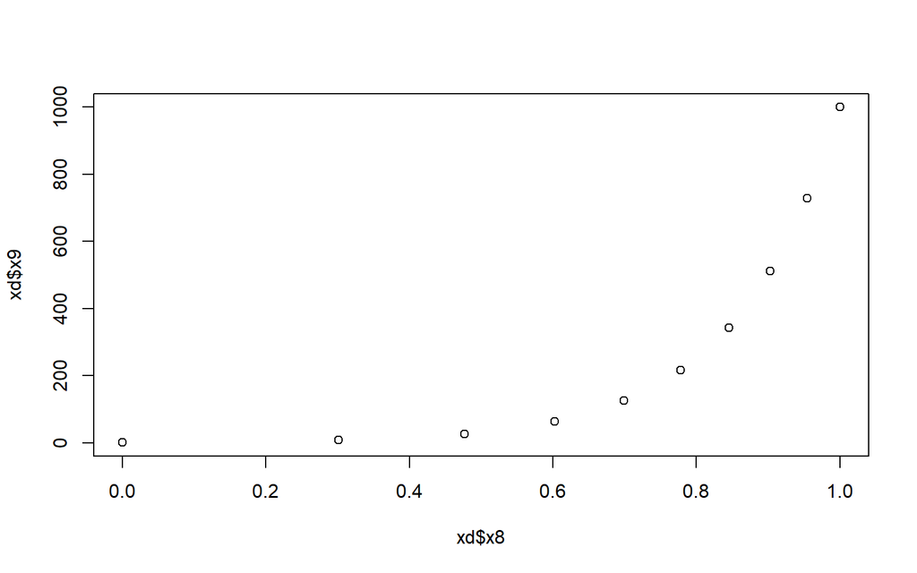

```r
# A basic scatter plot
plot(x = xd$x8, y = xd$x9)
```

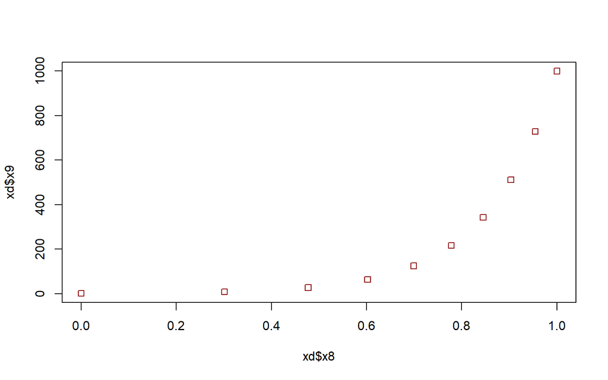

```r
# Adjust color and shape of the points
plot(x = xd$x8, y = xd$x9, col = "darkred", pch = 0)
```

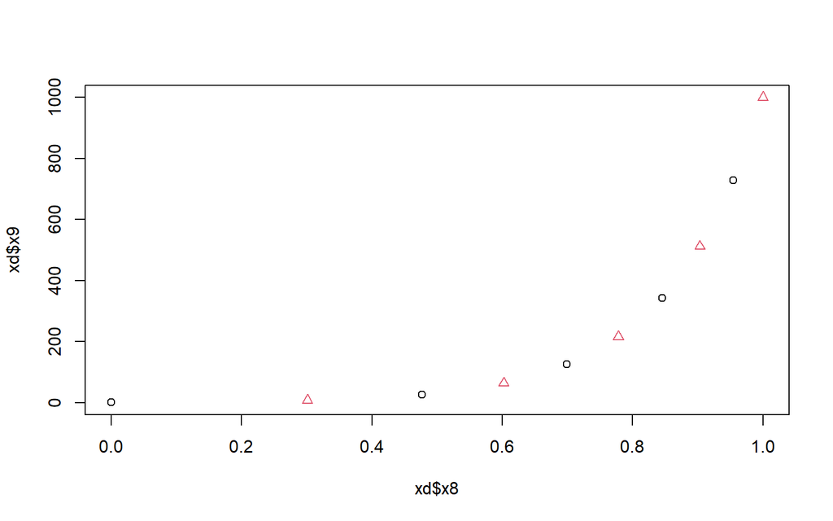

```r
plot(x = xd$x8, y = xd$x9, col = xd$x4, pch = xd$x4)
```

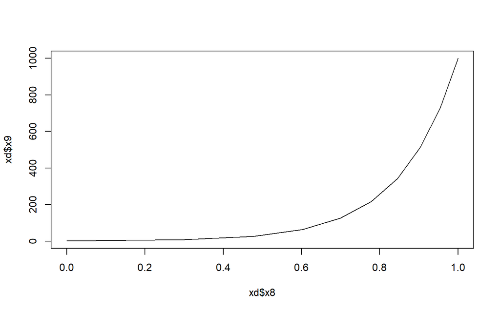

```r
# Adjust plot type
plot(x = xd$x8, y = xd$x9, type = "line")
```

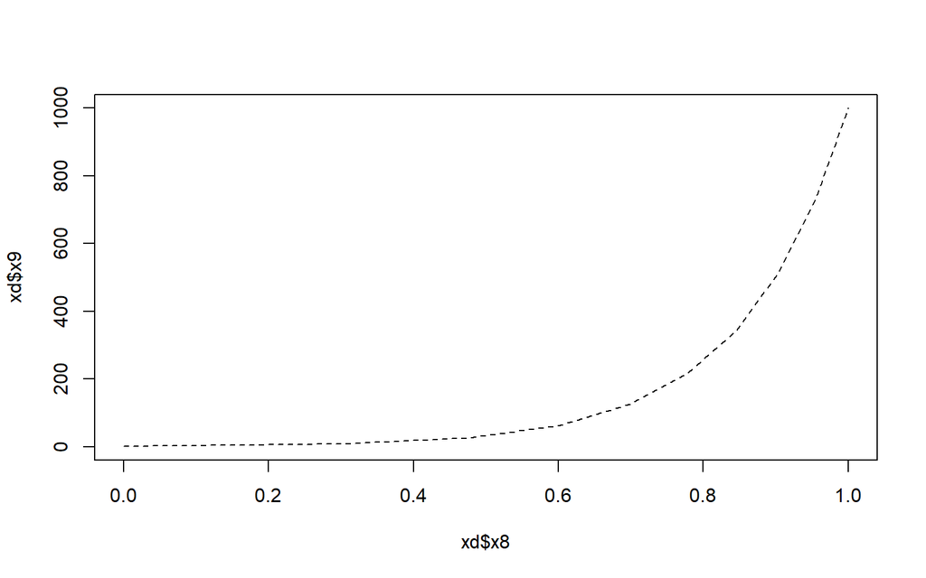

```r
# Adjust linetype
plot(x = xd$x8, y = xd$x9, type = "line", lty = 2)
```

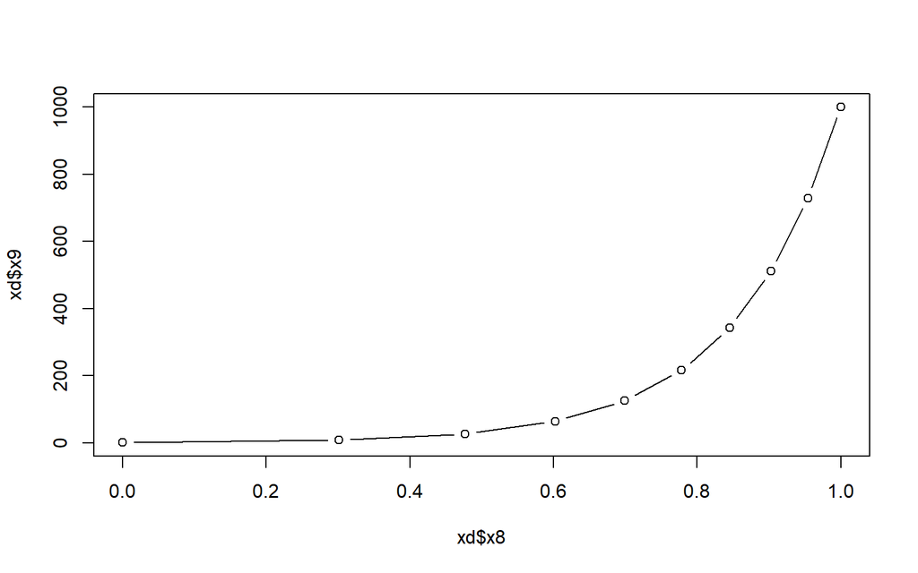

```r
# Plot lines and points
plot(x = xd$x8, y = xd$x9, type = "both")
```

Now lets create some random and normally distributed data to make some more complicated plots

```r
# 100 random uniformly distributed numbers ranging from 0 - 100
ru <- runif(100, min = 0, max = 100)
ru
```

```
##   [1] 29.104471 24.259186 96.977362 15.968213 98.050348 72.429526 76.421604 68.836075 28.287110 97.884976 33.151780 80.717384
##  [13] 59.924827 15.767733 26.649565 46.320874 10.372198 20.240548 64.127164 48.204185 52.851108 14.385488 19.567680 32.212756
##  [25] 62.353022 62.870381 28.903184 81.201140  2.599259  9.547201 81.384038 75.744842 88.302480 61.528131  1.491279 98.386188
##  [37]  3.216514 96.848258 95.378420 71.506513  1.819265 14.342637 13.833075  2.363248  6.014393 96.642777 14.473726 58.024450
##  [49] 39.450829 84.132475 53.108635 49.574149 95.642683 57.263316 96.253325 74.923844  6.001433 76.640424 71.690686 65.298702
##  [61] 14.497460 99.812033 92.654024 32.124228 98.185368 21.940985 37.640871 43.841161 34.053639 79.330998 65.105723 64.900773
##  [73] 90.561851 32.273547 28.037571 77.840350 15.289345 76.803197 80.112630  8.989100 45.336115 64.499365 47.667736 31.753033
##  [85] 36.410481 61.385362 45.941859 27.904776 88.907095 59.663387 96.126882 16.366181 39.637880 93.026507 45.552795 26.752586
##  [97] 61.638627 92.554197 28.609457 44.097903
```

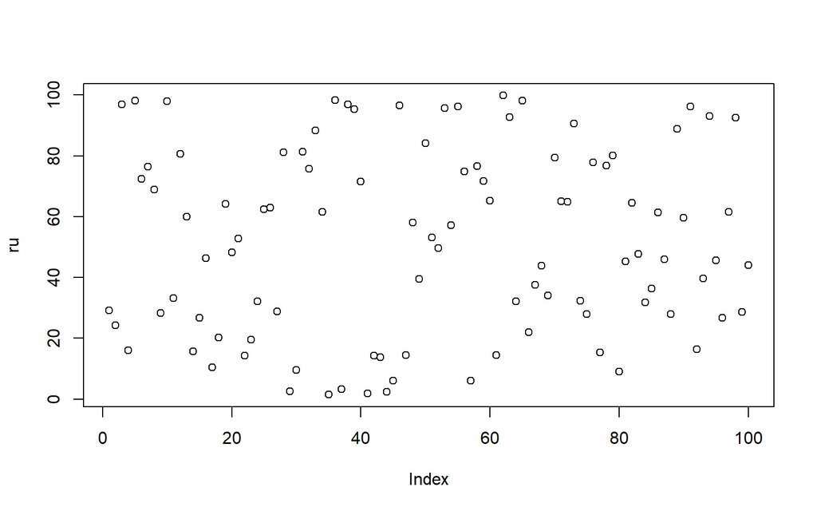

```r
plot(x = ru)
```

```r
order(ru)
```

```
##   [1]  35  41  44  29  37  57  45  80  30  17  43  42  22  47  61  77  14   4  92  23  18  66   2  15  96  88  75   9  99  27   1  84
##  [33]  64  24  74  11  69  85  67  49  93  68 100  81  95  87  16  83  20  52  21  51  54  48  90  13  86  34  97  25  26  19  82  72
##  [65]  71  60   8  40  59   6  56  32   7  58  78  76  70  79  12  28  31  50  33  89  73  98  63  94  39  53  91  55  46  38   3  10
##  [97]   5  65  36  62
```

```r
ru<- ru[order(ru)]
ru
```

```
##   [1]  1.491279  1.819265  2.363248  2.599259  3.216514  6.001433  6.014393  8.989100  9.547201 10.372198 13.833075 14.342637
##  [13] 14.385488 14.473726 14.497460 15.289345 15.767733 15.968213 16.366181 19.567680 20.240548 21.940985 24.259186 26.649565
##  [25] 26.752586 27.904776 28.037571 28.287110 28.609457 28.903184 29.104471 31.753033 32.124228 32.212756 32.273547 33.151780
##  [37] 34.053639 36.410481 37.640871 39.450829 39.637880 43.841161 44.097903 45.336115 45.552795 45.941859 46.320874 47.667736
##  [49] 48.204185 49.574149 52.851108 53.108635 57.263316 58.024450 59.663387 59.924827 61.385362 61.528131 61.638627 62.353022
##  [61] 62.870381 64.127164 64.499365 64.900773 65.105723 65.298702 68.836075 71.506513 71.690686 72.429526 74.923844 75.744842
##  [73] 76.421604 76.640424 76.803197 77.840350 79.330998 80.112630 80.717384 81.201140 81.384038 84.132475 88.302480 88.907095
##  [85] 90.561851 92.554197 92.654024 93.026507 95.378420 95.642683 96.126882 96.253325 96.642777 96.848258 96.977362 97.884976
##  [97] 98.050348 98.185368 98.386188 99.812033
```

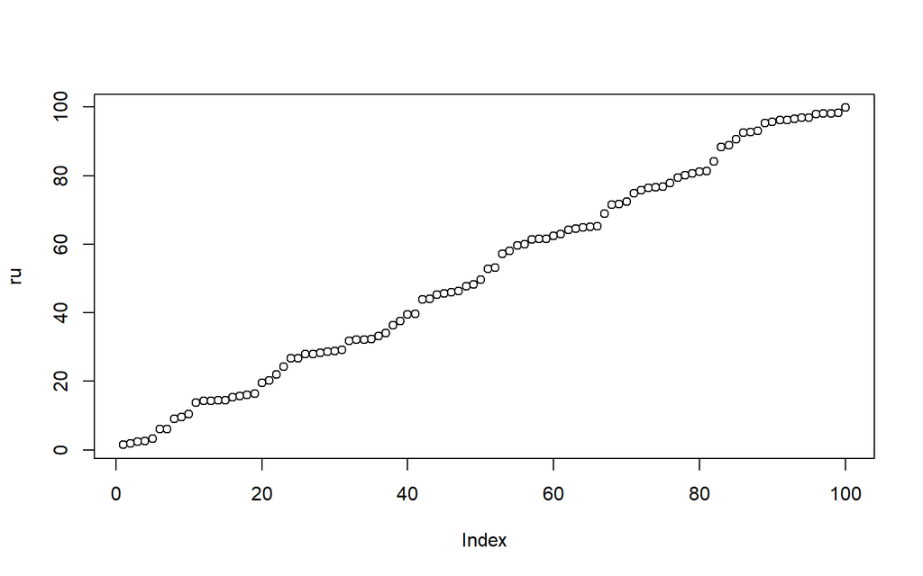

```r
plot(x = ru)
```

```r
# 100 normally distributed numbers with a mean of 50 and sd of 10
nd <- rnorm(100, mean = 50, sd = 10)
nd
```

```
##   [1] 51.91321 57.25516 46.08910 43.63974 54.51752 52.84274 47.40180 60.30795 44.68432 45.75816 48.98617 39.99565 48.27103 49.20797
##  [15] 29.83341 45.37470 46.73561 54.00725 45.50195 51.98091 54.10996 52.13781 41.34515 42.93723 54.46449 73.01522 58.79600 67.55397
##  [29] 32.42082 47.63238 30.60045 40.10792 44.76903 34.22291 50.83229 44.44289 52.46706 48.05277 63.01960 55.86017 71.59959 49.78064
##  [43] 48.53869 58.27944 56.63572 62.82474 52.33650 48.18715 53.43445 43.21023 38.40060 41.68488 49.21795 38.00845 83.22551 50.96592
##  [57] 57.76727 49.54372 49.42595 56.81161 54.94305 34.01631 55.67581 47.71948 40.75089 27.72964 60.35387 61.36137 55.95796 48.49808
##  [71] 32.07095 74.40927 43.68323 57.68750 63.37828 43.84544 52.94738 54.77301 52.56810 52.55919 45.02903 45.98966 28.37264 54.14115
##  [85] 57.21997 43.61163 50.10595 60.95282 49.62433 42.22956 43.49917 65.38289 72.96466 52.75949 54.56896 61.57907 46.62652 35.91952
##  [99] 62.95064 45.60893
```

```r
nd <- nd[order(nd)]
nd
```

```
##   [1] 27.72964 28.37264 29.83341 30.60045 32.07095 32.42082 34.01631 34.22291 35.91952 38.00845 38.40060 39.99565 40.10792 40.75089
##  [15] 41.34515 41.68488 42.22956 42.93723 43.21023 43.49917 43.61163 43.63974 43.68323 43.84544 44.44289 44.68432 44.76903 45.02903
##  [29] 45.37470 45.50195 45.60893 45.75816 45.98966 46.08910 46.62652 46.73561 47.40180 47.63238 47.71948 48.05277 48.18715 48.27103
##  [43] 48.49808 48.53869 48.98617 49.20797 49.21795 49.42595 49.54372 49.62433 49.78064 50.10595 50.83229 50.96592 51.91321 51.98091
##  [57] 52.13781 52.33650 52.46706 52.55919 52.56810 52.75949 52.84274 52.94738 53.43445 54.00725 54.10996 54.14115 54.46449 54.51752
##  [71] 54.56896 54.77301 54.94305 55.67581 55.86017 55.95796 56.63572 56.81161 57.21997 57.25516 57.68750 57.76727 58.27944 58.79600
##  [85] 60.30795 60.35387 60.95282 61.36137 61.57907 62.82474 62.95064 63.01960 63.37828 65.38289 67.55397 71.59959 72.96466 73.01522
##  [99] 74.40927 83.22551
```

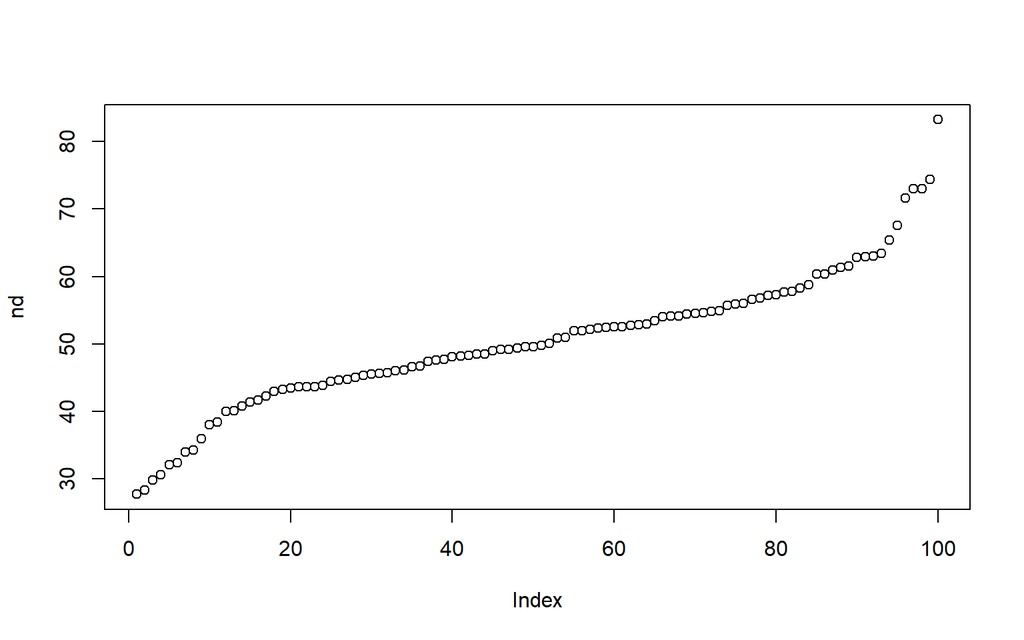

```r
plot(x = nd)
```

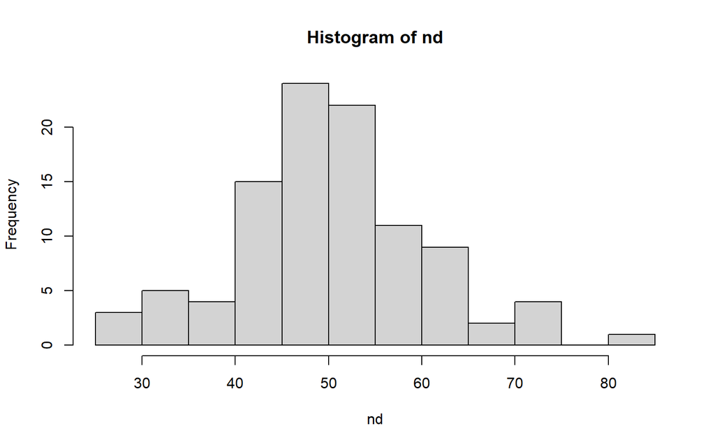

```r
hist(x = nd)
```

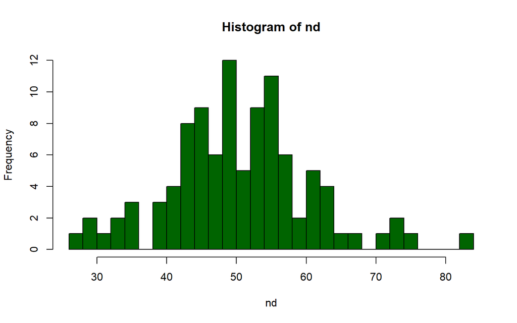

```r
hist(nd, breaks = 20, col = "darkgreen")
```

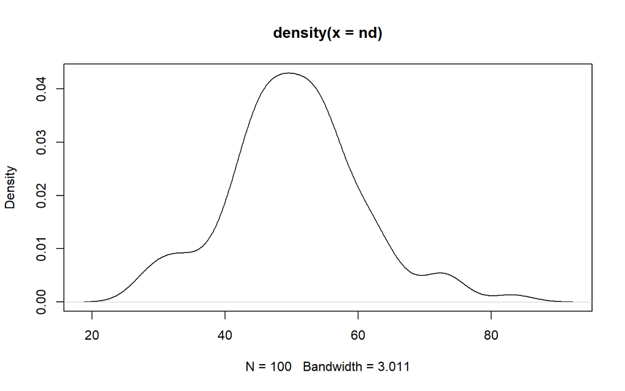

```r
plot(x = density(nd))
```

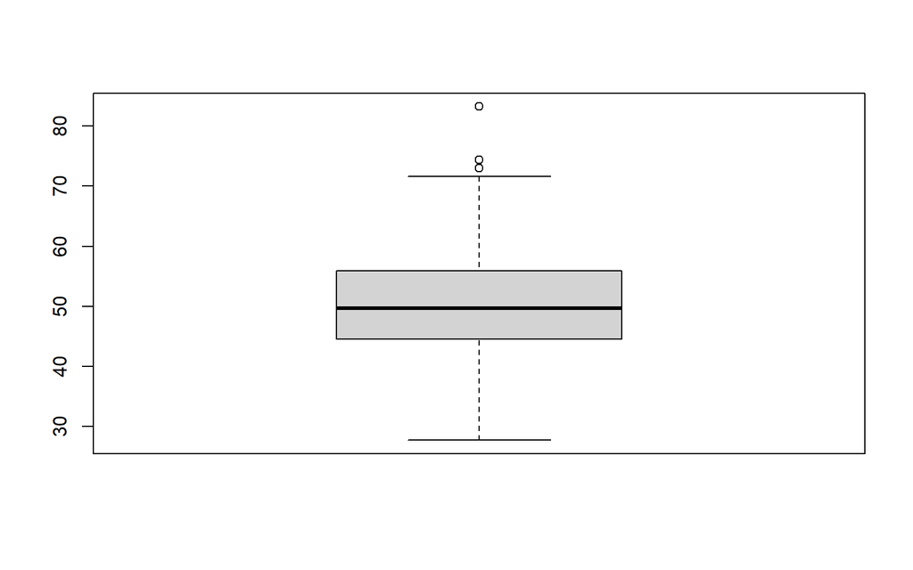

```r
boxplot(x = nd)
```

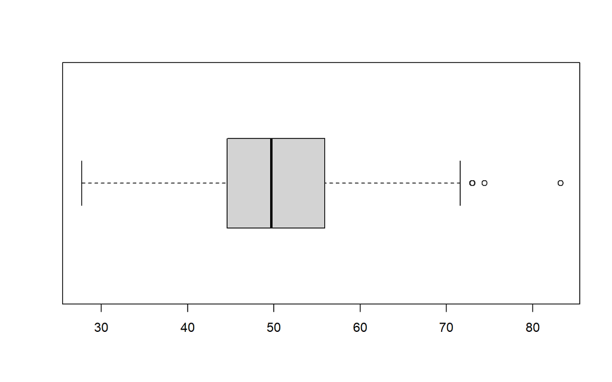

```r
boxplot(x = nd, horizontal = T)
```

# ggplot2

Lets be honest, the base plots are ugly! The `ggplot2` package gives the user to create a better, more visually appealing plots. Additional packages such as `ggbeeswarm` and `ggrepel` also contain useful functions to add to the functionality of `ggplot2`.

> - ggplot2 - https://ggplot2.tidyverse.org/
> - Tutorial 1 - http://r-statistics.co/ggplot2-Tutorial-With-R.html
> - Tutorial 2 - https://www.statsandr.com/blog/graphics-in-r-with-ggplot2/
> - The R Graph Gallery - https://www.r-graph-gallery.com/ggplot2-package.html

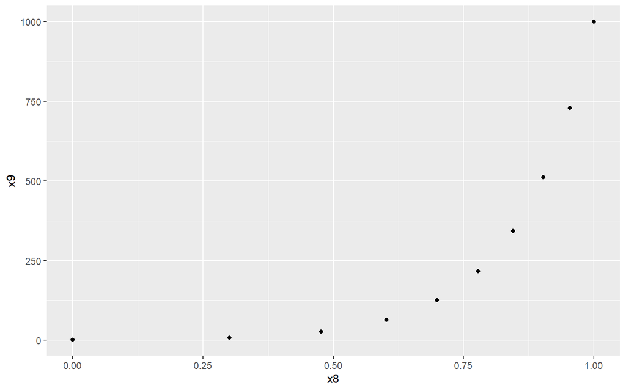

```r
library(ggplot2)
mp <- ggplot(xd, aes(x = x8, y = x9))
mp + geom_point()
```

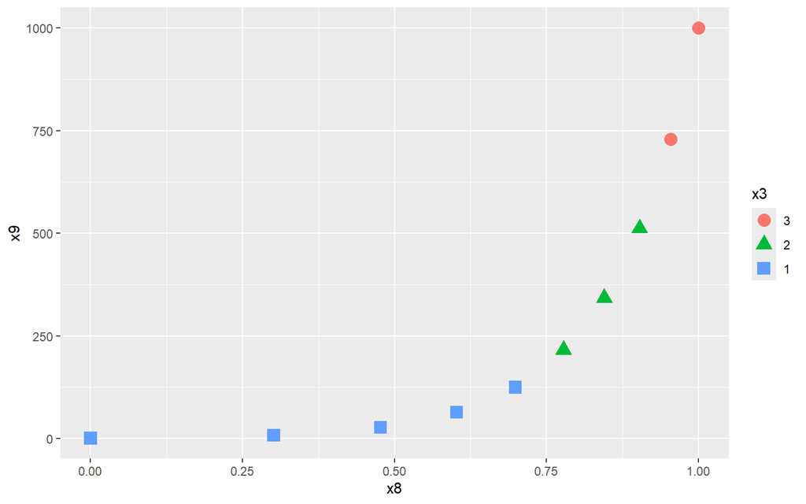

```r
mp + geom_point(aes(color = x3, shape = x3), size = 4)
```

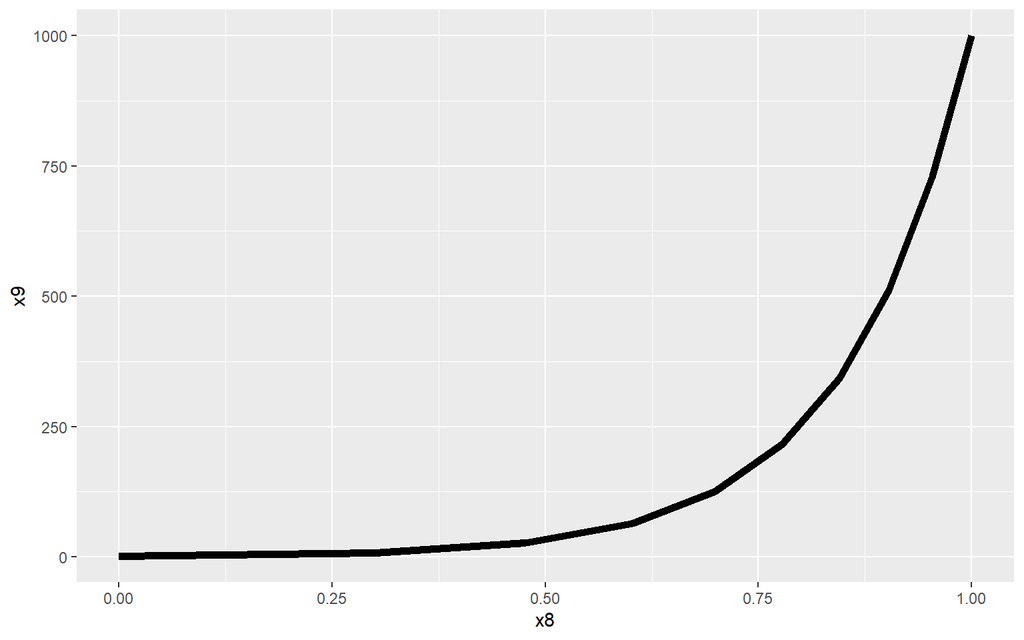

```r
mp + geom_line(size = 2)
```

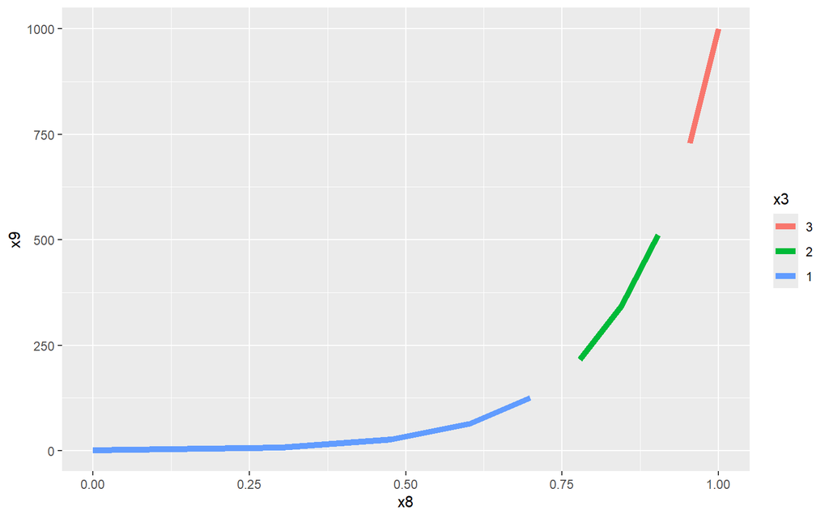

```r
mp + geom_line(aes(color = x3), size = 2)
```

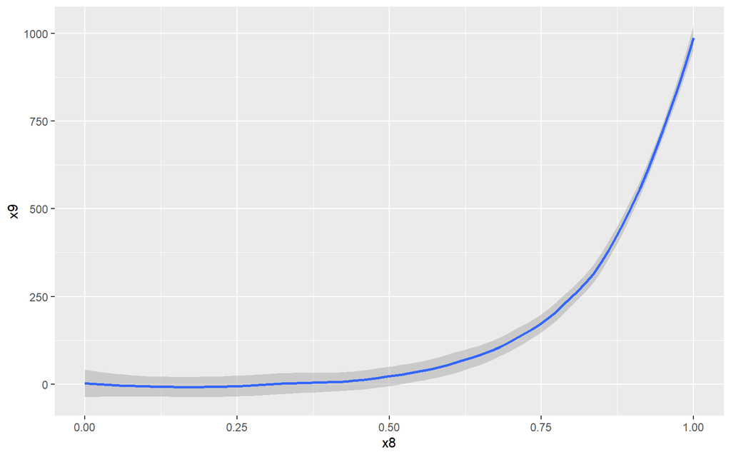

```r
mp + geom_smooth(method = "loess")
```

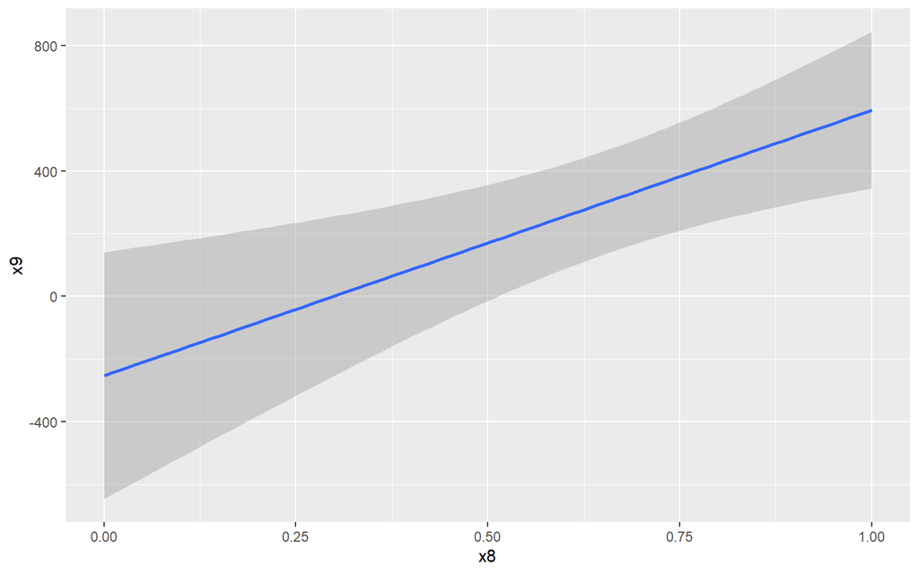

```r
mp + geom_smooth(method = "lm")
```

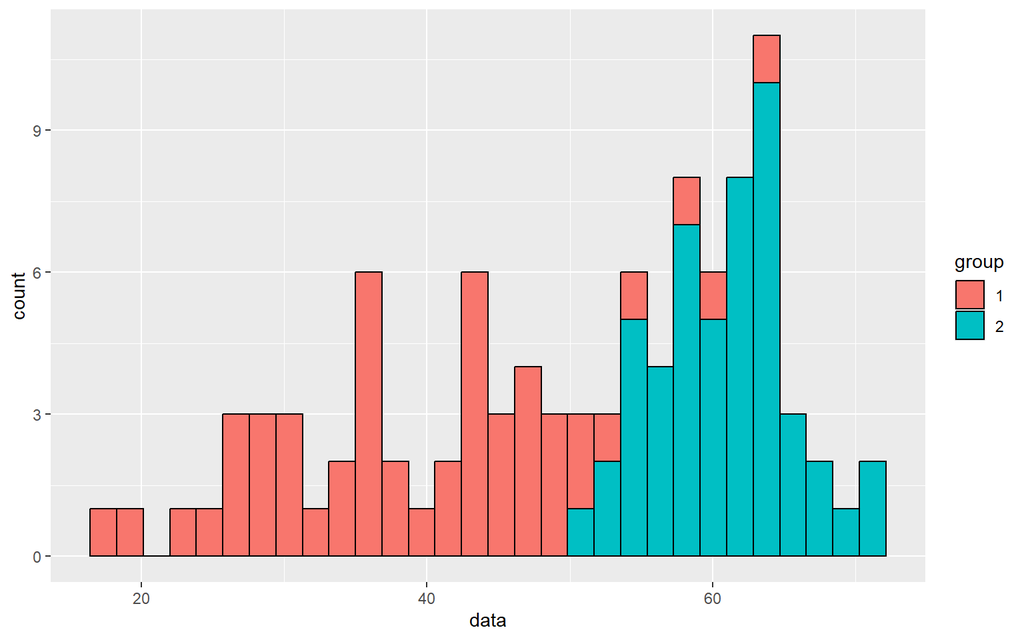

```r
xx <- data.frame(data = c(rnorm(50, mean = 40, sd = 10),
                          rnorm(50, mean = 60, sd = 5)),
                 group = factor(rep(1:2, each = 50)),
                 label = c("Label1", rep(NA, 49), "Label2", rep(NA, 49)))
mp <- ggplot(xx, aes(x = data, fill = group))
mp + geom_histogram(color = "black")
```

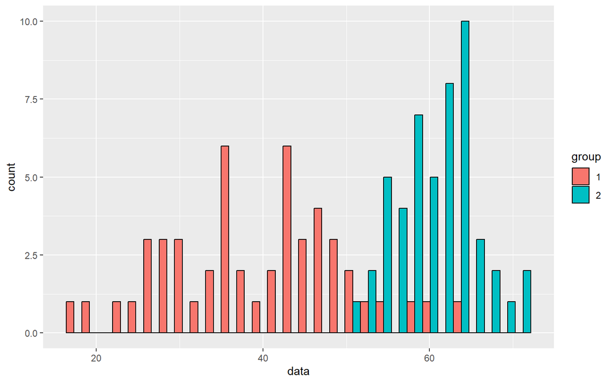

```r
mp + geom_histogram(color = "black", position = "dodge")
```

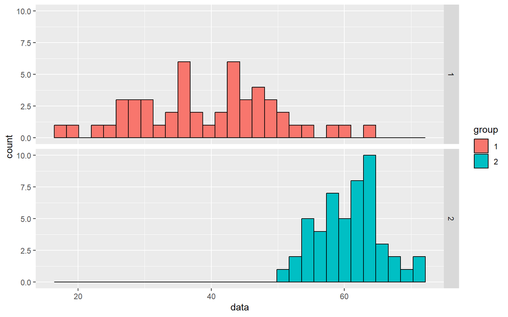

```r
mp1 <- mp + geom_histogram(color = "black") + facet_grid(group~.)
mp1
```

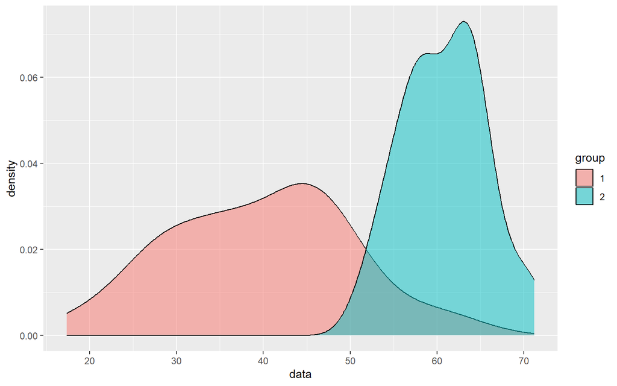

```r
mp + geom_density(alpha = 0.5)
```

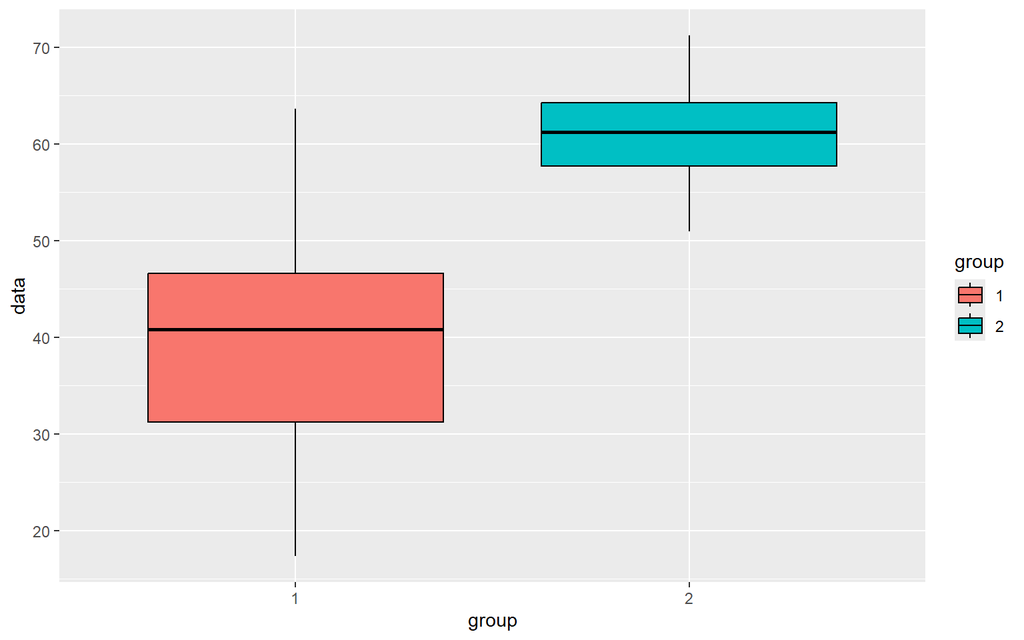

```r
mp <- ggplot(xx, aes(x = group, y = data, fill = group))
mp + geom_boxplot(color = "black")
```

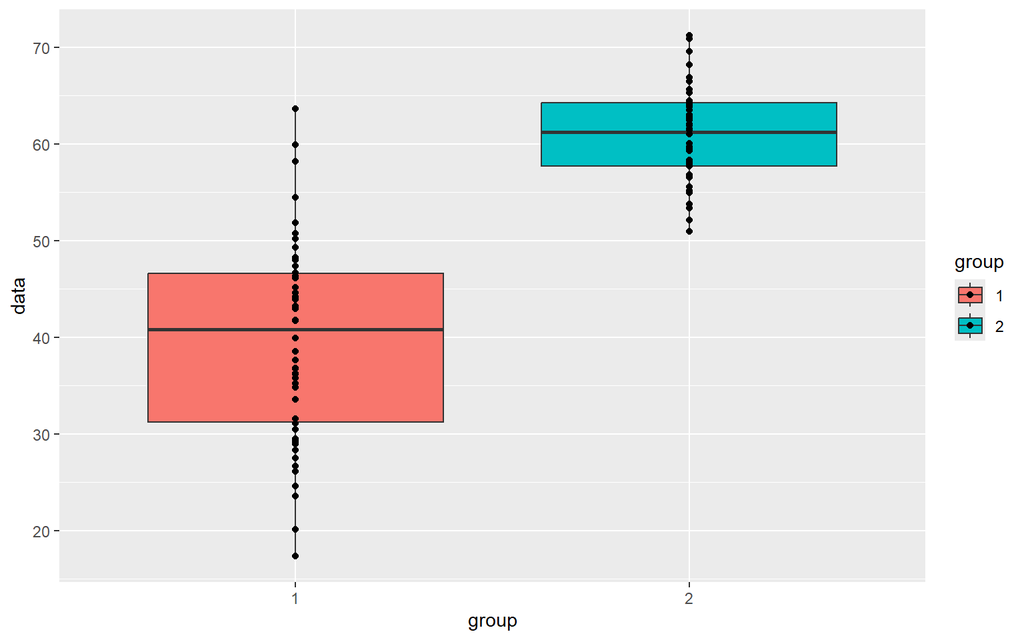

```r
mp + geom_boxplot() + geom_point()
```

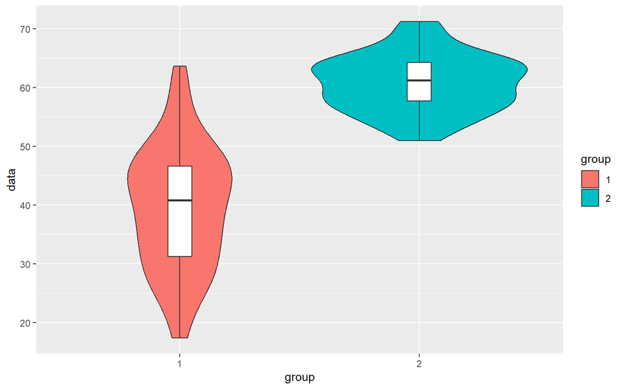

```r
mp + geom_violin() + geom_boxplot(width = 0.1, fill = "white")
```